# Risk Factor Analysis

## Outcome Variable

**Outcome Variable:** wast_rec90d

## Predictor Variables

**Intervention Variable:** vagbrth

**Adjustment Set:**

- arm
- sex
- W_mage
- meducyrs
- feducyrs
- hhwealth_quart
- W_mhtcm
- W_mwtkg
- W_mbmi
- single
- W_nrooms
- brthmon
- W_parity
- impfloor
- delta_W_mage
- delta_meducyrs
- delta_feducyrs
- delta_hhwealth_quart
- delta_W_mhtcm
- delta_W_mwtkg
- delta_W_mbmi
- delta_single
- delta_W_nrooms
- delta_brthmon
- delta_W_parity
- delta_impfloor

## Stratifying Variables

The analysis was stratified on these variable(s):

- agecat
- studyid
- country

## Data Summary

| agecat | studyid | country | vagbrth | wast_rec90d | n_cell | n |
| --- | --- | --- | --- | --- | --- | --- |
| 0-24 months | ki1000108-CMC-V-BCS-2002 | INDIA | 0 | 0 | 11 | 324 |
| 0-24 months | ki1000108-CMC-V-BCS-2002 | INDIA | 0 | 1 | 9 | 324 |
| 0-24 months | ki1000108-CMC-V-BCS-2002 | INDIA | 1 | 0 | 109 | 324 |
| 0-24 months | ki1000108-CMC-V-BCS-2002 | INDIA | 1 | 1 | 195 | 324 |
| 0-24 months | ki1000108-IRC | INDIA | 0 | 0 | 24 | 395 |
| 0-24 months | ki1000108-IRC | INDIA | 0 | 1 | 39 | 395 |
| 0-24 months | ki1000108-IRC | INDIA | 1 | 0 | 138 | 395 |
| 0-24 months | ki1000108-IRC | INDIA | 1 | 1 | 194 | 395 |
| 0-24 months | ki1017093b-PROVIDE | BANGLADESH | 0 | 0 | 25 | 308 |
| 0-24 months | ki1017093b-PROVIDE | BANGLADESH | 0 | 1 | 44 | 308 |
| 0-24 months | ki1017093b-PROVIDE | BANGLADESH | 1 | 0 | 104 | 308 |
| 0-24 months | ki1017093b-PROVIDE | BANGLADESH | 1 | 1 | 135 | 308 |
| 0-24 months | ki1017093c-NIH-Crypto | BANGLADESH | 0 | 0 | 18 | 189 |
| 0-24 months | ki1017093c-NIH-Crypto | BANGLADESH | 0 | 1 | 42 | 189 |
| 0-24 months | ki1017093c-NIH-Crypto | BANGLADESH | 1 | 0 | 58 | 189 |
| 0-24 months | ki1017093c-NIH-Crypto | BANGLADESH | 1 | 1 | 71 | 189 |
| 0-24 months | ki1066203-TanzaniaChild2 | TANZANIA, UNITED REPUBLIC OF | 0 | 0 | 24 | 705 |
| 0-24 months | ki1066203-TanzaniaChild2 | TANZANIA, UNITED REPUBLIC OF | 0 | 1 | 32 | 705 |
| 0-24 months | ki1066203-TanzaniaChild2 | TANZANIA, UNITED REPUBLIC OF | 1 | 0 | 240 | 705 |
| 0-24 months | ki1066203-TanzaniaChild2 | TANZANIA, UNITED REPUBLIC OF | 1 | 1 | 409 | 705 |
| 0-24 months | ki1119695-PROBIT | BELARUS | 0 | 0 | 68 | 4431 |
| 0-24 months | ki1119695-PROBIT | BELARUS | 0 | 1 | 391 | 4431 |
| 0-24 months | ki1119695-PROBIT | BELARUS | 1 | 0 | 547 | 4431 |
| 0-24 months | ki1119695-PROBIT | BELARUS | 1 | 1 | 3425 | 4431 |
| 0-24 months | ki1126311-ZVITAMBO | ZIMBABWE | 0 | 0 | 121 | 3582 |
| 0-24 months | ki1126311-ZVITAMBO | ZIMBABWE | 0 | 1 | 184 | 3582 |
| 0-24 months | ki1126311-ZVITAMBO | ZIMBABWE | 1 | 0 | 1512 | 3582 |
| 0-24 months | ki1126311-ZVITAMBO | ZIMBABWE | 1 | 1 | 1765 | 3582 |
| 0-24 months | kiGH5241-JiVitA-3 | BANGLADESH | 0 | 0 | 206 | 7547 |
| 0-24 months | kiGH5241-JiVitA-3 | BANGLADESH | 0 | 1 | 241 | 7547 |

[output cut: 78 more lines]

The following strata were considered:

- agecat: 0-24 months, studyid: ki1000108-CMC-V-BCS-2002, country: INDIA
- agecat: 0-24 months, studyid: ki1000108-IRC, country: INDIA
- agecat: 0-24 months, studyid: ki1017093b-PROVIDE, country: BANGLADESH
- agecat: 0-24 months, studyid: ki1017093c-NIH-Crypto, country: BANGLADESH
- agecat: 0-24 months, studyid: ki1066203-TanzaniaChild2, country: TANZANIA, UNITED REPUBLIC OF
- agecat: 0-24 months, studyid: ki1119695-PROBIT, country: BELARUS
- agecat: 0-24 months, studyid: ki1126311-ZVITAMBO, country: ZIMBABWE
- agecat: 0-24 months, studyid: kiGH5241-JiVitA-3, country: BANGLADESH
- agecat: 0-24 months, studyid: kiGH5241-JiVitA-4, country: BANGLADESH
- agecat: 0-6 months, studyid: ki1000108-CMC-V-BCS-2002, country: INDIA
- agecat: 0-6 months, studyid: ki1000108-IRC, country: INDIA
- agecat: 0-6 months, studyid: ki1017093b-PROVIDE, country: BANGLADESH
- agecat: 0-6 months, studyid: ki1017093c-NIH-Crypto, country: BANGLADESH
- agecat: 0-6 months, studyid: ki1066203-TanzaniaChild2, country: TANZANIA, UNITED REPUBLIC OF
- agecat: 0-6 months, studyid: ki1119695-PROBIT, country: BELARUS
- agecat: 0-6 months, studyid: ki1126311-ZVITAMBO, country: ZIMBABWE
- agecat: 0-6 months, studyid: kiGH5241-JiVitA-3, country: BANGLADESH
- agecat: 0-6 months, studyid: kiGH5241-JiVitA-4, country: BANGLADESH
- agecat: 6-24 months, studyid: ki1000108-CMC-V-BCS-2002, country: INDIA
- agecat: 6-24 months, studyid: ki1000108-IRC, country: INDIA
- agecat: 6-24 months, studyid: ki1017093b-PROVIDE, country: BANGLADESH
- agecat: 6-24 months, studyid: ki1017093c-NIH-Crypto, country: BANGLADESH
- agecat: 6-24 months, studyid: ki1066203-TanzaniaChild2, country: TANZANIA, UNITED REPUBLIC OF
- agecat: 6-24 months, studyid: ki1119695-PROBIT, country: BELARUS
- agecat: 6-24 months, studyid: ki1126311-ZVITAMBO, country: ZIMBABWE
- agecat: 6-24 months, studyid: kiGH5241-JiVitA-3, country: BANGLADESH
- agecat: 6-24 months, studyid: kiGH5241-JiVitA-4, country: BANGLADESH

### Dropped Strata

Some strata were dropped due to rare outcomes:

- agecat: 0-6 months, studyid: ki1017093c-NIH-Crypto, country: BANGLADESH
- agecat: 6-24 months, studyid: ki1000108-CMC-V-BCS-2002, country: INDIA
- agecat: 6-24 months, studyid: ki1017093b-PROVIDE, country: BANGLADESH
- agecat: 6-24 months, studyid: ki1119695-PROBIT, country: BELARUS
- agecat: 6-24 months, studyid: kiGH5241-JiVitA-3, country: BANGLADESH

## Methods Detail

We’re interested in the causal parameters $E[Y_a]$ for all values of $a \in \mathcal{A}$. These parameters represent the mean outcome if, possibly contrary to fact, we intervened to set all units to have $A=a$. Under the randomization and positivity assumptions, these are identified by the statistical parameters $\psi_a=E_W[E_{Y|A,W}(Y|A=a,W)]$. In addition, we’re interested in the mean of $Y$, $E[Y]$ under no intervention (the observed mean). We will estimate these parameters by using SuperLearner to fit the relevant likelihood factors – $E_{Y|A,W}(Y|A=a,W)$ and $p(A=a|W)$, and then updating our likelihood fit using a joint TMLE.

For unadjusted analyses ($W=\{\}$), initial likelihoods were estimated using Lrnr_glm to estimate the simple $E(Y|A)$ and Lrnr_mean to estimate $p(A)$. For adjusted analyses, a small library containing Lrnr_glmnet, Lrnr_xgboost, and Lrnr_mean was used.

Having estimated these parameters, we will then use the delta method to estimate relative risks and attributable risks relative to a prespecified baseline level of $A$.

# Results Detail

## Results Plots

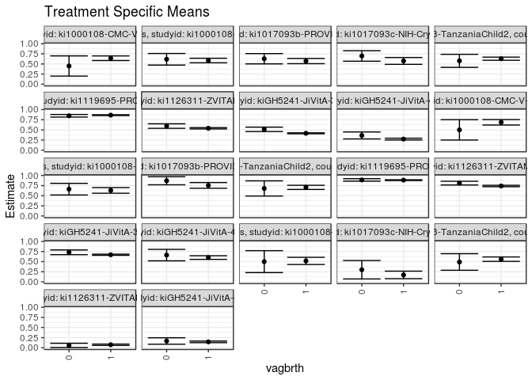

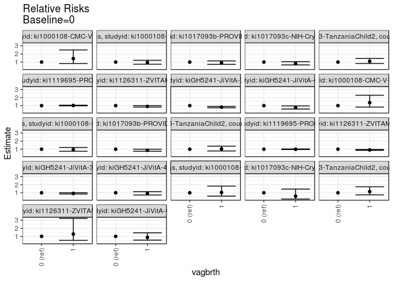

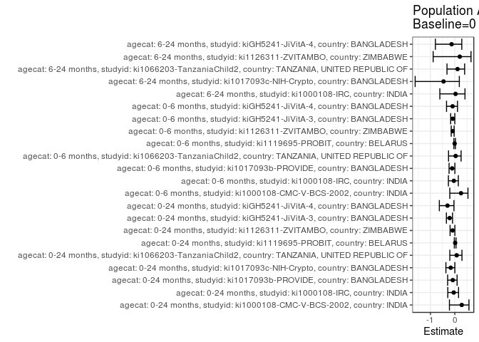

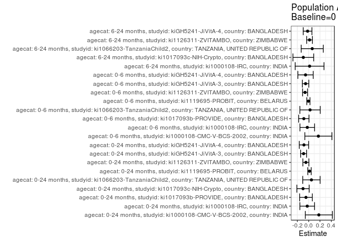

## Results Table

### Parameter: TSM

| agecat | studyid | country | intervention_level | baseline_level | estimate | ci_lower | ci_upper |
| --- | --- | --- | --- | --- | --- | --- | --- |
| 0-24 months | ki1000108-CMC-V-BCS-2002 | INDIA | 0 | NA | 0.4500000 | 0.2010987 | 0.6989013 |
| 0-24 months | ki1000108-CMC-V-BCS-2002 | INDIA | 1 | NA | 0.6414474 | 0.5845014 | 0.6983933 |
| 0-24 months | ki1000108-IRC | INDIA | 0 | NA | 0.6154800 | 0.4722822 | 0.7586777 |
| 0-24 months | ki1000108-IRC | INDIA | 1 | NA | 0.5848319 | 0.5286863 | 0.6409774 |
| 0-24 months | ki1017093b-PROVIDE | BANGLADESH | 0 | NA | 0.6291411 | 0.5025057 | 0.7557765 |
| 0-24 months | ki1017093b-PROVIDE | BANGLADESH | 1 | NA | 0.5714280 | 0.5073176 | 0.6355383 |
| 0-24 months | ki1017093c-NIH-Crypto | BANGLADESH | 0 | NA | 0.6977301 | 0.5683854 | 0.8270748 |
| 0-24 months | ki1017093c-NIH-Crypto | BANGLADESH | 1 | NA | 0.5746122 | 0.4897584 | 0.6594661 |
| 0-24 months | ki1066203-TanzaniaChild2 | TANZANIA, UNITED REPUBLIC OF | 0 | NA | 0.5768609 | 0.4162475 | 0.7374743 |
| 0-24 months | ki1066203-TanzaniaChild2 | TANZANIA, UNITED REPUBLIC OF | 1 | NA | 0.6295366 | 0.5902846 | 0.6687886 |
| 0-24 months | ki1119695-PROBIT | BELARUS | 0 | NA | 0.8472206 | 0.8152691 | 0.8791720 |
| 0-24 months | ki1119695-PROBIT | BELARUS | 1 | NA | 0.8628285 | 0.8521970 | 0.8734600 |
| 0-24 months | ki1126311-ZVITAMBO | ZIMBABWE | 0 | NA | 0.5933182 | 0.5377660 | 0.6488705 |
| 0-24 months | ki1126311-ZVITAMBO | ZIMBABWE | 1 | NA | 0.5389055 | 0.5217282 | 0.5560827 |
| 0-24 months | kiGH5241-JiVitA-3 | BANGLADESH | 0 | NA | 0.5123850 | 0.4580829 | 0.5666872 |
| 0-24 months | kiGH5241-JiVitA-3 | BANGLADESH | 1 | NA | 0.4155228 | 0.4040786 | 0.4269669 |
| 0-24 months | kiGH5241-JiVitA-4 | BANGLADESH | 0 | NA | 0.3618524 | 0.2754913 | 0.4482135 |
| 0-24 months | kiGH5241-JiVitA-4 | BANGLADESH | 1 | NA | 0.2715130 | 0.2494652 | 0.2935607 |
| 0-6 months | ki1000108-CMC-V-BCS-2002 | INDIA | 0 | NA | 0.5000000 | 0.2484317 | 0.7515683 |
| 0-6 months | ki1000108-CMC-V-BCS-2002 | INDIA | 1 | NA | 0.6864865 | 0.6188619 | 0.7541111 |
| 0-6 months | ki1000108-IRC | INDIA | 0 | NA | 0.6623040 | 0.5186984 | 0.8059096 |
| 0-6 months | ki1000108-IRC | INDIA | 1 | NA | 0.6316256 | 0.5619258 | 0.7013253 |
| 0-6 months | ki1017093b-PROVIDE | BANGLADESH | 0 | NA | 0.8695652 | 0.7698152 | 0.9693153 |
| 0-6 months | ki1017093b-PROVIDE | BANGLADESH | 1 | NA | 0.7553957 | 0.6854609 | 0.8253304 |
| 0-6 months | ki1066203-TanzaniaChild2 | TANZANIA, UNITED REPUBLIC OF | 0 | NA | 0.6800000 | 0.4929570 | 0.8670430 |
| 0-6 months | ki1066203-TanzaniaChild2 | TANZANIA, UNITED REPUBLIC OF | 1 | NA | 0.7064516 | 0.6550297 | 0.7578735 |
| 0-6 months | ki1119695-PROBIT | BELARUS | 0 | NA | 0.8905665 | 0.8607323 | 0.9204007 |
| 0-6 months | ki1119695-PROBIT | BELARUS | 1 | NA | 0.8851885 | 0.8750109 | 0.8953661 |
| 0-6 months | ki1126311-ZVITAMBO | ZIMBABWE | 0 | NA | 0.8113940 | 0.7652412 | 0.8575469 |
| 0-6 months | ki1126311-ZVITAMBO | ZIMBABWE | 1 | NA | 0.7408035 | 0.7229785 | 0.7586286 |
| 0-6 months | kiGH5241-JiVitA-3 | BANGLADESH | 0 | NA | 0.7298904 | 0.6716659 | 0.7881149 |
| 0-6 months | kiGH5241-JiVitA-3 | BANGLADESH | 1 | NA | 0.6701976 | 0.6562803 | 0.6841150 |
| 0-6 months | kiGH5241-JiVitA-4 | BANGLADESH | 0 | NA | 0.6613797 | 0.5198601 | 0.8028992 |
| 0-6 months | kiGH5241-JiVitA-4 | BANGLADESH | 1 | NA | 0.6002971 | 0.5554152 | 0.6451790 |
| 6-24 months | ki1000108-IRC | INDIA | 0 | NA | 0.5000000 | 0.2294903 | 0.7705097 |
| 6-24 months | ki1000108-IRC | INDIA | 1 | NA | 0.5179856 | 0.4297875 | 0.6061838 |
| 6-24 months | ki1017093c-NIH-Crypto | BANGLADESH | 0 | NA | 0.3000000 | 0.0725547 | 0.5274453 |
| 6-24 months | ki1017093c-NIH-Crypto | BANGLADESH | 1 | NA | 0.1724138 | 0.0793318 | 0.2654957 |
| 6-24 months | ki1066203-TanzaniaChild2 | TANZANIA, UNITED REPUBLIC OF | 0 | NA | 0.4916371 | 0.2874584 | 0.6958159 |
| 6-24 months | ki1066203-TanzaniaChild2 | TANZANIA, UNITED REPUBLIC OF | 1 | NA | 0.5607794 | 0.5061513 | 0.6154075 |
| 6-24 months | ki1126311-ZVITAMBO | ZIMBABWE | 0 | NA | 0.0588235 | 0.0060316 | 0.1116154 |
| 6-24 months | ki1126311-ZVITAMBO | ZIMBABWE | 1 | NA | 0.0753012 | 0.0590916 | 0.0915108 |
| 6-24 months | kiGH5241-JiVitA-4 | BANGLADESH | 0 | NA | 0.1670843 | 0.0870016 | 0.2471669 |
| 6-24 months | kiGH5241-JiVitA-4 | BANGLADESH | 1 | NA | 0.1462374 | 0.1263973 | 0.1660774 |

### Parameter: E(Y)

| agecat | studyid | country | intervention_level | baseline_level | estimate | ci_lower | ci_upper |
| --- | --- | --- | --- | --- | --- | --- | --- |
| 0-24 months | ki1000108-CMC-V-BCS-2002 | INDIA | NA | NA | 0.6296296 | 0.5734927 | 0.6857666 |
| 0-24 months | ki1000108-IRC | INDIA | NA | NA | 0.5898734 | 0.5376978 | 0.6420491 |
| 0-24 months | ki1017093b-PROVIDE | BANGLADESH | NA | NA | 0.5811688 | 0.5245443 | 0.6377934 |
| 0-24 months | ki1017093c-NIH-Crypto | BANGLADESH | NA | NA | 0.5978836 | 0.5264156 | 0.6693516 |
| 0-24 months | ki1066203-TanzaniaChild2 | TANZANIA, UNITED REPUBLIC OF | NA | NA | 0.6255319 | 0.5876598 | 0.6634040 |
| 0-24 months | ki1119695-PROBIT | BELARUS | NA | NA | 0.8612051 | 0.8511051 | 0.8713052 |
| 0-24 months | ki1126311-ZVITAMBO | ZIMBABWE | NA | NA | 0.5441094 | 0.5276459 | 0.5605730 |
| 0-24 months | kiGH5241-JiVitA-3 | BANGLADESH | NA | NA | 0.4225520 | 0.4114127 | 0.4336913 |
| 0-24 months | kiGH5241-JiVitA-4 | BANGLADESH | NA | NA | 0.2782123 | 0.2567662 | 0.2996583 |
| 0-6 months | ki1000108-CMC-V-BCS-2002 | INDIA | NA | NA | 0.6716418 | 0.6057305 | 0.7375531 |
| 0-6 months | ki1000108-IRC | INDIA | NA | NA | 0.6375000 | 0.5751450 | 0.6998550 |
| 0-6 months | ki1017093b-PROVIDE | BANGLADESH | NA | NA | 0.7837838 | 0.7252863 | 0.8422812 |
| 0-6 months | ki1066203-TanzaniaChild2 | TANZANIA, UNITED REPUBLIC OF | NA | NA | 0.7044776 | 0.6548846 | 0.7540707 |
| 0-6 months | ki1119695-PROBIT | BELARUS | NA | NA | 0.8855266 | 0.8758983 | 0.8951550 |
| 0-6 months | ki1126311-ZVITAMBO | ZIMBABWE | NA | NA | 0.7473011 | 0.7302821 | 0.7643201 |
| 0-6 months | kiGH5241-JiVitA-3 | BANGLADESH | NA | NA | 0.6752064 | 0.6618507 | 0.6885622 |
| 0-6 months | kiGH5241-JiVitA-4 | BANGLADESH | NA | NA | 0.6058824 | 0.5634305 | 0.6483342 |
| 6-24 months | ki1000108-IRC | INDIA | NA | NA | 0.5161290 | 0.4322562 | 0.6000019 |
| 6-24 months | ki1017093c-NIH-Crypto | BANGLADESH | NA | NA | 0.2051282 | 0.1132549 | 0.2970015 |
| 6-24 months | ki1066203-TanzaniaChild2 | TANZANIA, UNITED REPUBLIC OF | NA | NA | 0.5540541 | 0.5015831 | 0.6065250 |
| 6-24 months | ki1126311-ZVITAMBO | ZIMBABWE | NA | NA | 0.0740056 | 0.0585029 | 0.0895082 |
| 6-24 months | kiGH5241-JiVitA-4 | BANGLADESH | NA | NA | 0.1476563 | 0.1284384 | 0.1668741 |

### Parameter: RR

| agecat | studyid | country | intervention_level | baseline_level | estimate | ci_lower | ci_upper |
| --- | --- | --- | --- | --- | --- | --- | --- |
| 0-24 months | ki1000108-CMC-V-BCS-2002 | INDIA | 0 | 0 | 1.0000000 | 1.0000000 | 1.0000000 |
| 0-24 months | ki1000108-CMC-V-BCS-2002 | INDIA | 1 | 0 | 1.4254386 | 0.8141162 | 2.4958048 |
| 0-24 months | ki1000108-IRC | INDIA | 0 | 0 | 1.0000000 | 1.0000000 | 1.0000000 |
| 0-24 months | ki1000108-IRC | INDIA | 1 | 0 | 0.9502045 | 0.7386863 | 1.2222898 |
| 0-24 months | ki1017093b-PROVIDE | BANGLADESH | 0 | 0 | 1.0000000 | 1.0000000 | 1.0000000 |
| 0-24 months | ki1017093b-PROVIDE | BANGLADESH | 1 | 0 | 0.9082668 | 0.7209619 | 1.1442334 |
| 0-24 months | ki1017093c-NIH-Crypto | BANGLADESH | 0 | 0 | 1.0000000 | 1.0000000 | 1.0000000 |
| 0-24 months | ki1017093c-NIH-Crypto | BANGLADESH | 1 | 0 | 0.8235451 | 0.6497411 | 1.0438413 |
| 0-24 months | ki1066203-TanzaniaChild2 | TANZANIA, UNITED REPUBLIC OF | 0 | 0 | 1.0000000 | 1.0000000 | 1.0000000 |
| 0-24 months | ki1066203-TanzaniaChild2 | TANZANIA, UNITED REPUBLIC OF | 1 | 0 | 1.0913143 | 0.8204041 | 1.4516833 |
| 0-24 months | ki1119695-PROBIT | BELARUS | 0 | 0 | 1.0000000 | 1.0000000 | 1.0000000 |
| 0-24 months | ki1119695-PROBIT | BELARUS | 1 | 0 | 1.0184225 | 0.9789590 | 1.0594769 |
| 0-24 months | ki1126311-ZVITAMBO | ZIMBABWE | 0 | 0 | 1.0000000 | 1.0000000 | 1.0000000 |
| 0-24 months | ki1126311-ZVITAMBO | ZIMBABWE | 1 | 0 | 0.9082908 | 0.8231988 | 1.0021785 |
| 0-24 months | kiGH5241-JiVitA-3 | BANGLADESH | 0 | 0 | 1.0000000 | 1.0000000 | 1.0000000 |
| 0-24 months | kiGH5241-JiVitA-3 | BANGLADESH | 1 | 0 | 0.8109580 | 0.7268693 | 0.9047746 |
| 0-24 months | kiGH5241-JiVitA-4 | BANGLADESH | 0 | 0 | 1.0000000 | 1.0000000 | 1.0000000 |
| 0-24 months | kiGH5241-JiVitA-4 | BANGLADESH | 1 | 0 | 0.7503417 | 0.5831055 | 0.9655418 |
| 0-6 months | ki1000108-CMC-V-BCS-2002 | INDIA | 0 | 0 | 1.0000000 | 1.0000000 | 1.0000000 |
| 0-6 months | ki1000108-CMC-V-BCS-2002 | INDIA | 1 | 0 | 1.3729730 | 0.8222475 | 2.2925636 |
| 0-6 months | ki1000108-IRC | INDIA | 0 | 0 | 1.0000000 | 1.0000000 | 1.0000000 |
| 0-6 months | ki1000108-IRC | INDIA | 1 | 0 | 0.9536792 | 0.7474229 | 1.2168532 |
| 0-6 months | ki1017093b-PROVIDE | BANGLADESH | 0 | 0 | 1.0000000 | 1.0000000 | 1.0000000 |
| 0-6 months | ki1017093b-PROVIDE | BANGLADESH | 1 | 0 | 0.8687050 | 0.7496395 | 1.0066819 |
| 0-6 months | ki1066203-TanzaniaChild2 | TANZANIA, UNITED REPUBLIC OF | 0 | 0 | 1.0000000 | 1.0000000 | 1.0000000 |
| 0-6 months | ki1066203-TanzaniaChild2 | TANZANIA, UNITED REPUBLIC OF | 1 | 0 | 1.0388994 | 0.7816335 | 1.3808416 |
| 0-6 months | ki1119695-PROBIT | BELARUS | 0 | 0 | 1.0000000 | 1.0000000 | 1.0000000 |
| 0-6 months | ki1119695-PROBIT | BELARUS | 1 | 0 | 0.9939611 | 0.9593860 | 1.0297823 |
| 0-6 months | ki1126311-ZVITAMBO | ZIMBABWE | 0 | 0 | 1.0000000 | 1.0000000 | 1.0000000 |
| 0-6 months | ki1126311-ZVITAMBO | ZIMBABWE | 1 | 0 | 0.9130010 | 0.8597991 | 0.9694948 |
| 0-6 months | kiGH5241-JiVitA-3 | BANGLADESH | 0 | 0 | 1.0000000 | 1.0000000 | 1.0000000 |
| 0-6 months | kiGH5241-JiVitA-3 | BANGLADESH | 1 | 0 | 0.9182168 | 0.8455623 | 0.9971141 |
| 0-6 months | kiGH5241-JiVitA-4 | BANGLADESH | 0 | 0 | 1.0000000 | 1.0000000 | 1.0000000 |
| 0-6 months | kiGH5241-JiVitA-4 | BANGLADESH | 1 | 0 | 0.9076438 | 0.7234637 | 1.1387126 |
| 6-24 months | ki1000108-IRC | INDIA | 0 | 0 | 1.0000000 | 1.0000000 | 1.0000000 |
| 6-24 months | ki1000108-IRC | INDIA | 1 | 0 | 1.0359712 | 0.5874383 | 1.8269773 |
| 6-24 months | ki1017093c-NIH-Crypto | BANGLADESH | 0 | 0 | 1.0000000 | 1.0000000 | 1.0000000 |
| 6-24 months | ki1017093c-NIH-Crypto | BANGLADESH | 1 | 0 | 0.5747126 | 0.2266054 | 1.4575764 |
| 6-24 months | ki1066203-TanzaniaChild2 | TANZANIA, UNITED REPUBLIC OF | 0 | 0 | 1.0000000 | 1.0000000 | 1.0000000 |
| 6-24 months | ki1066203-TanzaniaChild2 | TANZANIA, UNITED REPUBLIC OF | 1 | 0 | 1.1406367 | 0.7453726 | 1.7455058 |
| 6-24 months | ki1126311-ZVITAMBO | ZIMBABWE | 0 | 0 | 1.0000000 | 1.0000000 | 1.0000000 |
| 6-24 months | ki1126311-ZVITAMBO | ZIMBABWE | 1 | 0 | 1.2801205 | 0.5086675 | 3.2215712 |
| 6-24 months | kiGH5241-JiVitA-4 | BANGLADESH | 0 | 0 | 1.0000000 | 1.0000000 | 1.0000000 |
| 6-24 months | kiGH5241-JiVitA-4 | BANGLADESH | 1 | 0 | 0.8752313 | 0.5317988 | 1.4404507 |

### Parameter: PAR

| agecat | studyid | country | intervention_level | baseline_level | estimate | ci_lower | ci_upper |
| --- | --- | --- | --- | --- | --- | --- | --- |
| 0-24 months | ki1000108-CMC-V-BCS-2002 | INDIA | 0 | NA | 0.1796296 | -0.0595047 | 0.4187640 |
| 0-24 months | ki1000108-IRC | INDIA | 0 | NA | -0.0256066 | -0.1552321 | 0.1040190 |
| 0-24 months | ki1017093b-PROVIDE | BANGLADESH | 0 | NA | -0.0479723 | -0.1601757 | 0.0642312 |
| 0-24 months | ki1017093c-NIH-Crypto | BANGLADESH | 0 | NA | -0.0998465 | -0.2083865 | 0.0086935 |
| 0-24 months | ki1066203-TanzaniaChild2 | TANZANIA, UNITED REPUBLIC OF | 0 | NA | 0.0486710 | -0.1051944 | 0.2025365 |
| 0-24 months | ki1119695-PROBIT | BELARUS | 0 | NA | 0.0139846 | -0.0162583 | 0.0442275 |
| 0-24 months | ki1126311-ZVITAMBO | ZIMBABWE | 0 | NA | -0.0492088 | -0.1023738 | 0.0039562 |
| 0-24 months | kiGH5241-JiVitA-3 | BANGLADESH | 0 | NA | -0.0898330 | -0.1428073 | -0.0368588 |
| 0-24 months | kiGH5241-JiVitA-4 | BANGLADESH | 0 | NA | -0.0836401 | -0.1662788 | -0.0010014 |
| 0-6 months | ki1000108-CMC-V-BCS-2002 | INDIA | 0 | NA | 0.1716418 | -0.0677857 | 0.4110693 |
| 0-6 months | ki1000108-IRC | INDIA | 0 | NA | -0.0248040 | -0.1539341 | 0.1043261 |
| 0-6 months | ki1017093b-PROVIDE | BANGLADESH | 0 | NA | -0.0857814 | -0.1775631 | 0.0060003 |
| 0-6 months | ki1066203-TanzaniaChild2 | TANZANIA, UNITED REPUBLIC OF | 0 | NA | 0.0244776 | -0.1550298 | 0.2039850 |
| 0-6 months | ki1119695-PROBIT | BELARUS | 0 | NA | -0.0050399 | -0.0333697 | 0.0232899 |
| 0-6 months | ki1126311-ZVITAMBO | ZIMBABWE | 0 | NA | -0.0640930 | -0.1082542 | -0.0199317 |
| 0-6 months | kiGH5241-JiVitA-3 | BANGLADESH | 0 | NA | -0.0546839 | -0.1116125 | 0.0022446 |
| 0-6 months | kiGH5241-JiVitA-4 | BANGLADESH | 0 | NA | -0.0554973 | -0.1907079 | 0.0797133 |
| 6-24 months | ki1000108-IRC | INDIA | 0 | NA | 0.0161290 | -0.2390237 | 0.2712818 |
| 6-24 months | ki1017093c-NIH-Crypto | BANGLADESH | 0 | NA | -0.0948718 | -0.2780930 | 0.0883494 |
| 6-24 months | ki1066203-TanzaniaChild2 | TANZANIA, UNITED REPUBLIC OF | 0 | NA | 0.0624169 | -0.1328224 | 0.2576563 |
| 6-24 months | ki1126311-ZVITAMBO | ZIMBABWE | 0 | NA | 0.0151820 | -0.0357019 | 0.0660660 |
| 6-24 months | kiGH5241-JiVitA-4 | BANGLADESH | 0 | NA | -0.0194280 | -0.0967170 | 0.0578610 |

### Parameter: PAF

| agecat | studyid | country | intervention_level | baseline_level | estimate | ci_lower | ci_upper |
| --- | --- | --- | --- | --- | --- | --- | --- |
| 0-24 months | ki1000108-CMC-V-BCS-2002 | INDIA | 0 | NA | 0.2852941 | -0.2199966 | 0.5813066 |
| 0-24 months | ki1000108-IRC | INDIA | 0 | NA | -0.0434103 | -0.2877141 | 0.1545444 |
| 0-24 months | ki1017093b-PROVIDE | BANGLADESH | 0 | NA | -0.0825444 | -0.2939145 | 0.0942968 |
| 0-24 months | ki1017093c-NIH-Crypto | BANGLADESH | 0 | NA | -0.1669999 | -0.3649382 | 0.0022341 |
| 0-24 months | ki1066203-TanzaniaChild2 | TANZANIA, UNITED REPUBLIC OF | 0 | NA | 0.0778074 | -0.2045160 | 0.2939578 |
| 0-24 months | ki1119695-PROBIT | BELARUS | 0 | NA | 0.0162384 | -0.0195148 | 0.0507378 |
| 0-24 months | ki1126311-ZVITAMBO | ZIMBABWE | 0 | NA | -0.0904391 | -0.1927222 | 0.0030726 |
| 0-24 months | kiGH5241-JiVitA-3 | BANGLADESH | 0 | NA | -0.2125964 | -0.3447160 | -0.0934577 |
| 0-24 months | kiGH5241-JiVitA-4 | BANGLADESH | 0 | NA | -0.3006341 | -0.6340695 | -0.0352369 |
| 0-6 months | ki1000108-CMC-V-BCS-2002 | INDIA | 0 | NA | 0.2555556 | -0.2051932 | 0.5401588 |
| 0-6 months | ki1000108-IRC | INDIA | 0 | NA | -0.0389083 | -0.2625863 | 0.1451433 |
| 0-6 months | ki1017093b-PROVIDE | BANGLADESH | 0 | NA | -0.1094453 | -0.2348561 | 0.0032289 |
| 0-6 months | ki1066203-TanzaniaChild2 | TANZANIA, UNITED REPUBLIC OF | 0 | NA | 0.0347458 | -0.2569309 | 0.2587375 |
| 0-6 months | ki1119695-PROBIT | BELARUS | 0 | NA | -0.0056914 | -0.0381984 | 0.0257978 |
| 0-6 months | ki1126311-ZVITAMBO | ZIMBABWE | 0 | NA | -0.0857659 | -0.1466825 | -0.0280855 |
| 0-6 months | kiGH5241-JiVitA-3 | BANGLADESH | 0 | NA | -0.0809885 | -0.1687261 | 0.0001626 |
| 0-6 months | kiGH5241-JiVitA-4 | BANGLADESH | 0 | NA | -0.0915975 | -0.3393612 | 0.1103333 |
| 6-24 months | ki1000108-IRC | INDIA | 0 | NA | 0.0312500 | -0.6139924 | 0.4185372 |
| 6-24 months | ki1017093c-NIH-Crypto | BANGLADESH | 0 | NA | -0.4625000 | -1.6271554 | 0.1858471 |
| 6-24 months | ki1066203-TanzaniaChild2 | TANZANIA, UNITED REPUBLIC OF | 0 | NA | 0.1126549 | -0.3208304 | 0.4038740 |
| 6-24 months | ki1126311-ZVITAMBO | ZIMBABWE | 0 | NA | 0.2051471 | -0.8882704 | 0.6654127 |
| 6-24 months | kiGH5241-JiVitA-4 | BANGLADESH | 0 | NA | -0.1315759 | -0.7969229 | 0.2874129 |